# CMA - Exercise 4

Author

kinmar01

exercise 4, part of the course cma (mainly based on Laube (2014))

# 1 **Input: Segmentation**

You’ve read Laube and Purves (2011) about segmenting trajectories. In the paper, the authors define “ *static* ” fixes as “ * those whose average Euclidean distance to other fixes inside a temporal window v is less than some threshold d * ”, as illustrated in Figure 1

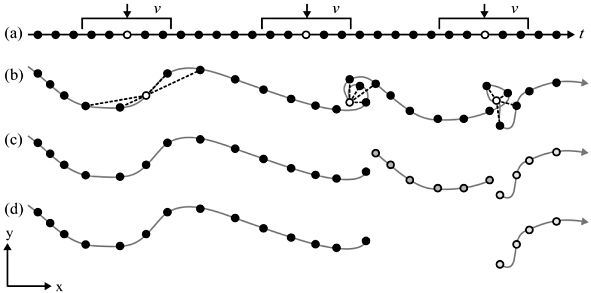

1. Specify a temporal windows v for in which to measure Euclidean distances.
2. Measure the distance from every point to every other point within this temporal window v.
3. Remove “static points”:These are points where the average distance is less than a given threshold. This segments the trajectory into subtrajectories.
4. Now remove short subtrajectories:These are trajectories with a short duration (whereas “short” is tbd).

We will ** demonstrate ** implementing this method on the wild boar “Sabi”, restricting ourselves to a couple of tracking days. Your task will be to understand this implementation and apply it to your own movement data.

Open a RStudio Project for this week. Next, copy the wild boar data you downloaded last week ( *wildschwein_BE_2056.csv* ) to your project folder. If you cannot find this dataset on your computer, you can re - download it from moodle. Transform the data into an `sf` object, filter for the wild boar Sabi and a datetime between “2015 - 07 - 01” and “2015 - 07 - 03”.

```r
pacman::p_load("readr", "sf", "dplyr", "ggplot2","RColorBrewer","tidyr")

theme_minimal() |> theme_set()
```

```r
wildschwein <- read_delim("data/wildschwein_BE_2056.csv", ",")
# Careful! What Timezone is assumed?
sabi <- wildschwein |>
st_as_sf(coords = c("E", "N"),
crs = 2056,
remove = FALSE) |>
filter(TierName == "Sabi",
DatetimeUTC >= "2015-07-01",
DatetimeUTC < "2015-07-03")

sabi |> summary()
```

```
    TierID            TierName            CollarID
 Length:192         Length:192         Min.   :12275
 Class :character   Class :character   1st Qu.:12275
 Mode  :character   Mode  :character   Median :12275
                                       Mean   :12275
                                       3rd Qu.:12275
                                       Max.   :12275
  DatetimeUTC                           E                 N
 Min.   :2015-06-30 22:00:13.00   Min.   :2569724   Min.   :1204916
 1st Qu.:2015-07-01 09:56:28.50   1st Qu.:2569791   1st Qu.:1205121
 Median :2015-07-01 21:52:58.50   Median :2570466   Median :1205140
 Mean   :2015-07-01 21:52:50.82   Mean   :2570242   Mean   :1205172
 3rd Qu.:2015-07-02 09:49:05.75   3rd Qu.:2570475   3rd Qu.:1205180
 Max.   :2015-07-02 21:45:16.00   Max.   :2570927   Max.   :1205957
          geometry
 POINT        :192
 epsg:2056    :  0
 +proj=some...:  0
```

```r
sabi |> str()
```

```
sf [192 × 7] (S3: sf/spec_tbl_df/tbl_df/tbl/data.frame)
 $ TierID     : chr [1:192] "002A" "002A" "002A" "002A" ...
 $ TierName   : chr [1:192] "Sabi" "Sabi" "Sabi" "Sabi" ...
 $ CollarID   : num [1:192] 12275 12275 12275 12275 12275 ...
 $ DatetimeUTC: POSIXct[1:192], format: "2015-06-30 22:00:13" "2015-06-30 22:16:06" ...
 $ E          : num [1:192] 2569972 2569975 2570266 2570208 2570247 ...
 $ N          : num [1:192] 1205366 1205637 1205857 1205913 1205731 ...
 $ geometry   :sfc_POINT of length 192; first list element:  'XY' num [1:2] 2569972 1205366
 - attr(*, "spec")=
  .. cols(
  ..   TierID = col_character(),
  ..   TierName = col_character(),
  ..   CollarID = col_double(),
  ..   DatetimeUTC = col_datetime(format = ""),
  ..   E = col_double(),
  ..   N = col_double()
  .. )
 - attr(*, "problems")=<externalptr>
 - attr(*, "sf_column")= chr "geometry"
 - attr(*, "agr")= Factor w/ 3 levels "constant","aggregate",..: NA NA NA NA NA NA
  ..- attr(*, "names")= chr [1:6] "TierID" "TierName" "CollarID" "DatetimeUTC" ...
```

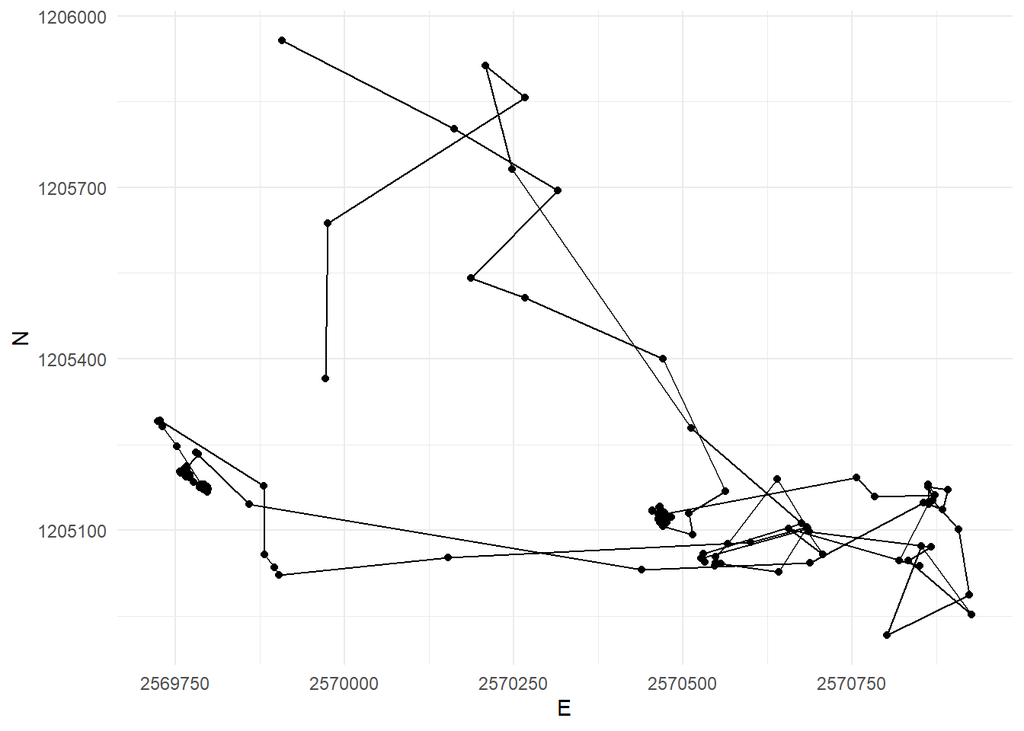

Figure 2: Movement of the wild boar ‘Sabi’ in the timespan 01 - 02.07.2015. The cluster of dots / fixes are possible ‘static’ points

```r
sabi |>
ggplot(aes(E, N)) +
geom_point() +
geom_path() +
theme_minimal()
```

**Step a): Specify a temporal window** v

In the above dataset, the sampling interval is 15 minutes. If we take a temporal window of 60 minutes, that would mean including 4 fixes. We need to calculate the following Euclidean distances (pos representing single location):

1. `pos[n-2]` to `pos[n]`
2. `pos[n-1]` to `pos[n]`
3. `pos[n]` to `pos[n+1]`
4. `pos[n]` to `pos[n+2]`

**Step b): Measure the distance to every point within** v

We can use the function distance_by_element from week 2 in combination with `lead()` and `lag()` to calculate the Euclidean distance. For example, to create the necessary offset of n-2, we use `lag(x, 2)`. For each offset, we create one individual column.

```r
distance_by_element <- function(later, now) {
  as.numeric(
    st_distance(later, now, by_element = TRUE)
  )
}


sabi <- sabi |>
  mutate(
    nMinus2 = distance_by_element(lag(geometry,2),geometry),
    nMinus1 = distance_by_element(lag(geometry,1),geometry),
    nPlus1 = distance_by_element(geometry,lead(geometry,1)),
    nPlus2 = distance_by_element(geometry,lead(geometry,2))
  )
```

Now we want to calculate the mean distance of `nMinus2`, `nMinus1`, `nPlus1`, `nPlus2` for each row. Since we want the mean value *per Row*, we have to explicitly specify this before `mutate()` with the function `rowwise()`. To remove this rowwise-grouping, we end the operation with `ungroup()`.

Note that for the first two positions, we cannot calculate a `stepMean` since there is no Position `n-2` for these positions. This is also true for the last to positions (lacking a position `n+2`).

```r
sabi <- sabi |>
  rowwise() |>
  mutate(
    stepMean = mean(c(nMinus2, nMinus1, nPlus1, nPlus2))
  ) |>
  ungroup()
```

**Step c): Remove “static points”**

We can now determine if an animal is moving or not by specifying a threshold distance on `stepMean`. In our example, we use the mean value as a threshold: Positions with distances below this value are considered static.

```r
sabi <- sabi |>
  mutate(static = stepMean < mean(stepMean, na.rm = TRUE))

sabi_moving <- sabi |>
  filter(!static)

sabi_static <- sabi |>
  filter(static)
```

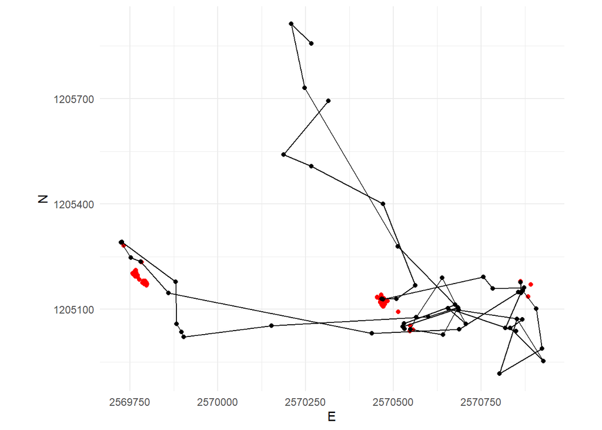

Figure 3: The trajectory of sabi. Red dots are static points, the black dots signify moving points

```r
sabi_moving |>
  ggplot(aes(E, N)) +
  geom_point(data = sabi_static, col = "red") +
  geom_path() +
  geom_point() +
  coord_fixed() +
  theme(legend.position = "bottom")
```

# 2 **Exercise A: Segmentation**

With the skills from Input: Segmentation you can now implement the segmentation algorithm described in Laube and Purves (2011) to either your own movement data or to a different wild boar using different sampling intervals.

## 2.1 **Task 1: Calculate distances**

Now, you can Step a): Specify a temporal window v and Step b): Measure the distance to every point within v, which you had used with sabi, on on your own movement data or to a different wild boar using different sampling intervals.

```r
df_tannenhaeher <- read_delim("tannenhaeher.csv") |>
  st_as_sf(coords = c("x", "y"), crs = 2056, remove = FALSE)
df_tannenhaeher_K125864 <- df_tannenhaeher |>
  filter(ind_ident=="K125864")

df_tannenhaeher_K121752 <- df_tannenhaeher |>
  filter(ind_ident=="K121752")
```

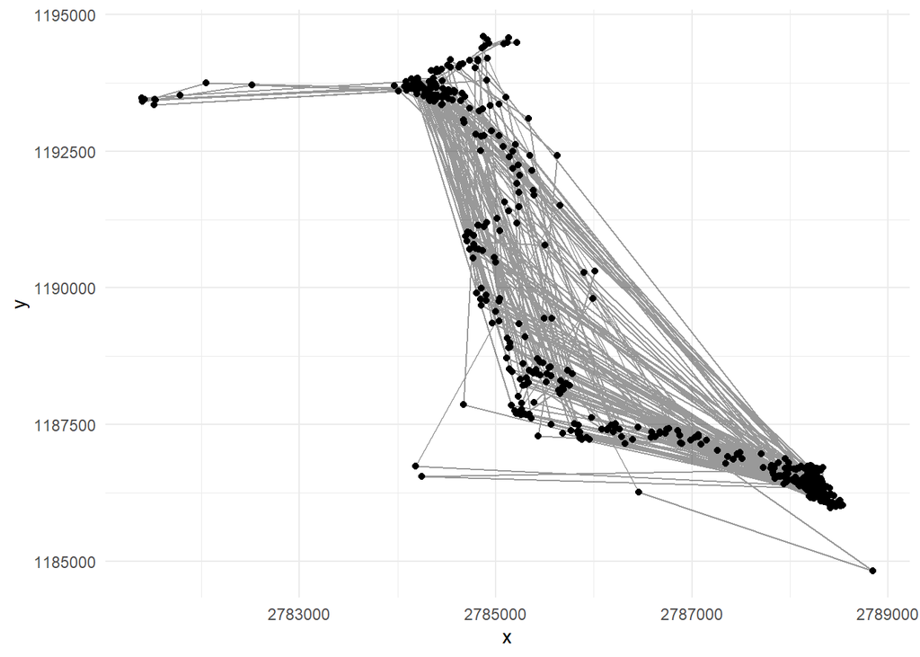

Figure 4: Movement of the Spotted Nutcracker K125864. The cluster of dots / fixes are possible ‘static’ points

```r
df_tannenhaeher_K125864 |>
  ggplot(aes(x,y)) +
  geom_point() +
  geom_path(alpha=0.4)
```

**move or stop**

Ask chatGPT for a reasonable threshold beside mean, median and Q1

```r
steps <- function(df) {
  df_updated <- df |>
    mutate(
      nMinus2 = distance_by_element(lag(geometry,2),geometry),
      nMinus1 = distance_by_element(lag(geometry,1),geometry),
      nPlus1 = distance_by_element(geometry,lead(geometry,1)),
      nPlus2 = distance_by_element(geometry,lead(geometry,2))
    ) |>
    rowwise() |>
    mutate(
      stepMean = mean(c(nMinus2, nMinus1, nPlus1, nPlus2))
    ) |>
    ungroup()|>
    mutate(
      mean = mean(stepMean, na.rm = TRUE),
      median = median(stepMean, na.rm = TRUE),
      Q1 = quantile(stepMean, 0.25, na.rm = TRUE),
      static = stepMean < Q1
    )

  return (df_updated)
}


df_tannenhaeher_K125864 <- df_tannenhaeher_K125864 |> steps()
df_tannenhaeher_K121752 <- df_tannenhaeher_K121752 |> steps()
```

## 2.2 **Task 2: Specify and apply threshold *d***

After calculating the Euclidean distances to positions within the temporal window *v* in task 1, you can explore these values (we stored them in the column `stepMean`) using summary statistics (histograms, boxplot, `summary()`): This way we can define a reasonable threshold value to differentiate between *stops* and *moves*. There is no “correct” way of doing this, specifying a threshold always depends on data as well as the question that needs to be answered. In this exercise, use the mean of all `stepMean` values.

Store the new information (boolean to differentiate between stops (`TRUE`) and moves (`FALSE`)) in a new column named `static`.

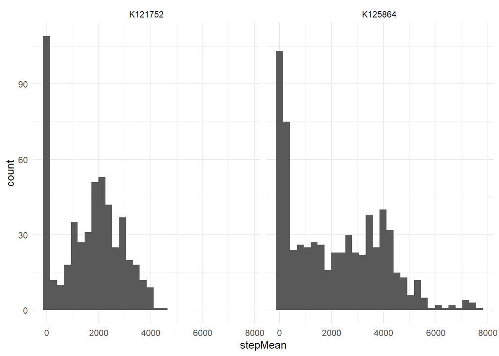

(a) Histogram

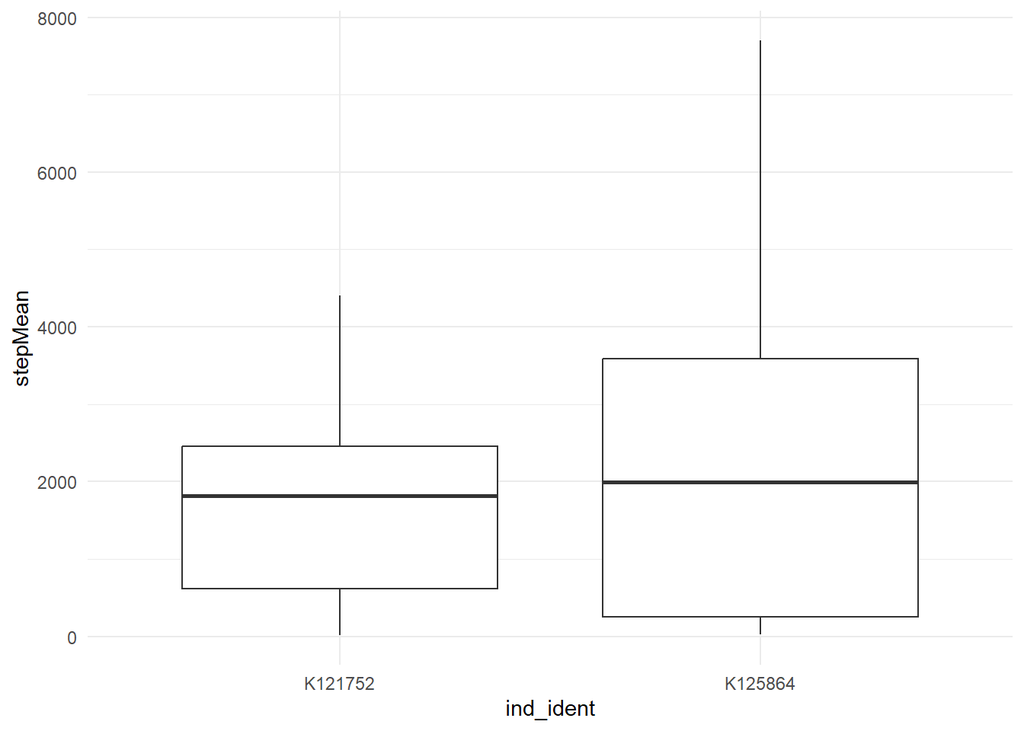

(b) Boxplot

Figure 5: Summary statistics for both spotted Nutcracker

```r
df_spotted_nutcracker <- union(
  df_tannenhaeher_K121752,
  df_tannenhaeher_K125864
)

df_spotted_nutcracker|>
  ggplot(aes(stepMean)) +
  geom_histogram() +
  facet_wrap(.~ind_ident)
df_spotted_nutcracker |>
  ggplot(aes(ind_ident,stepMean))+
  geom_boxplot()
```

## 2.3 **Task 3: Visualize segmented trajectories**

Now visualize the segmented trajectory spatially. Just like last week, you can use ggplot with `geom_path()`, `geom_point()` and `coord_equal()`. Assign `colour = static` within `aes()` to distinguish between segments *with* “movement” and *without*.

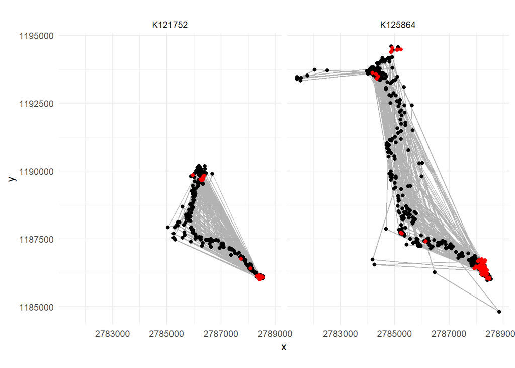

Figure 6: The trajectory of Spotted Nutcracker K125864 & K121752.. Red dots are static points, the black dots signify moving points

```r
df_spotted_nutcracker|>
  filter(!static) |>
  ggplot(aes(x, y)) +
  geom_path(alpha=0.3) +
  geom_point() +
  geom_point(data = df_spotted_nutcracker |> filter(static), col = "red") +
  coord_equal()+
  facet_wrap(.~ind_ident)
```

## 2.4 **Task 4: Segment-based analysis**

In applying Laube and Purves (2011), we’ve come as far as step b) in Figure 1. In order to complete the last steps (c and d), we need a *unique* ID for each segment that we can use as a grouping variable. The following function does just that (it assigns unique IDs based on the column `static` which you created in Task 2). You will learn about functions next week. For now, just copy the following code chunk into your script and run it.

```r
rle_id <- function(vec) {
    x <- rle(vec)$lengths
    as.factor(rep(seq_along(x), times = x))
}
```

You can use the newly created function rle_id to assign unique IDs to subtrajectories (as shown below). Visualize the moving segments by colourizing them by segment_ID. Then use segment_ID as a grouping variable to determine the segments duration and remove short segments (e.g. segments with a duration < 5 Minutes)

```r
df_spotted_nutcracker_v2 <- union(
  df_tannenhaeher_K121752|>
    mutate(segment_id = rle_id(static)),
  df_tannenhaeher_K125864|>
    mutate(segment_id = rle_id(static))
)
```

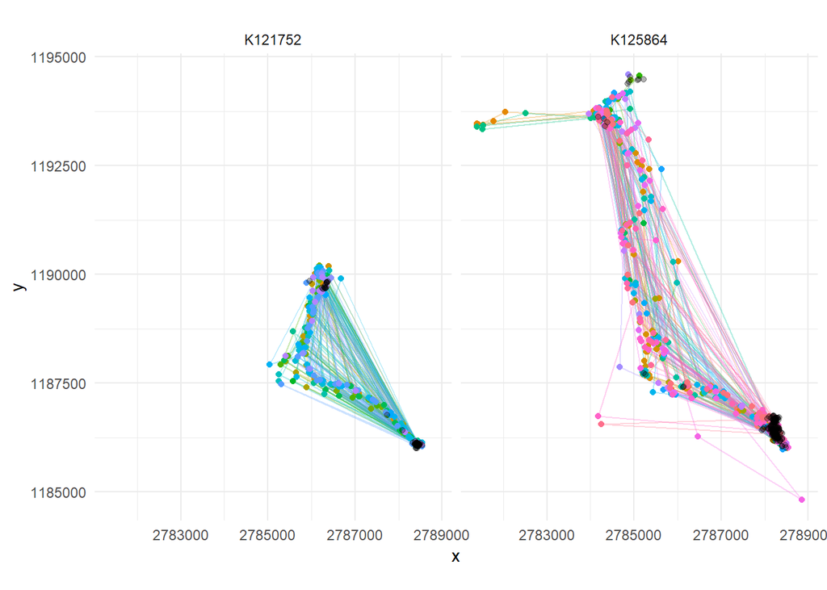

Figure 7: The trajectory of Spotted Nutcracker K125864 & K121752. Black dots are static points, moving points and trajectories are colorized by segment

```r
df_spotted_nutcracker_v2|>
  filter(!static) |>
  ggplot(aes(x, y, color=segment_id)) +
  geom_path(alpha=0.3) +
  geom_point() +
  geom_point(data = df_spotted_nutcracker |> filter(static), col = "black",alpha=0.3) +
  coord_equal()+
  facet_wrap(.~ind_ident)+
  theme(legend.position = "none")
```

```r
df_spotted_nutcracker_v2 <- df_spotted_nutcracker_v2 |>
  group_by(segment_id,ind_ident) |>
  mutate(
    duration = last(timestamp)-first(timestamp)
  ) |>
  ungroup()
```

# 3 **Exercise B: Similarity**

## 3.1 **Task 1: Similarity measures**

We will now calculate similarties between trajectories using a new dataset pedestrian.csv (available on moodle). Download an import this dataset as a `data.frame` or `tibble`. It it a set of six different but similar trajectories from pedestrians walking on a path.

For this task, explore the trajectories in Figure 8 first and get an idea on how the pedestrians moved.

```r
df_pedestrian <- read_delim("data/pedestrian.csv") |>
  mutate(TrajID = as.factor(TrajID)) |>
  st_as_sf(coords = c("E", "N"),crs = 2056,remove = FALSE)
```

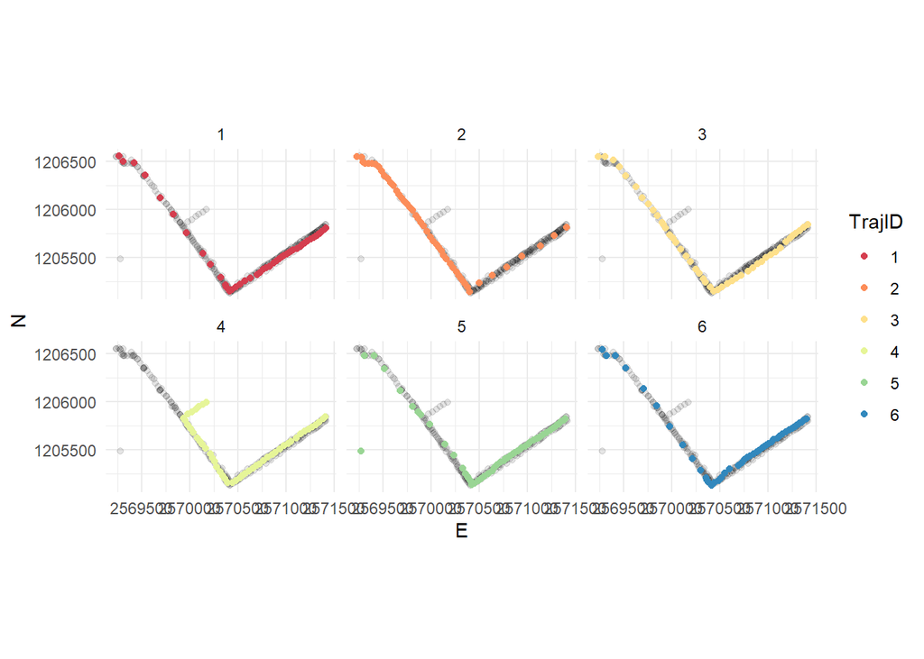

Figure 8: Visual comparison of 6 trajectories. Each subplot highlights a trajectory

```r
df_pedestrian |>
  ggplot(aes(E,N))+
  geom_point(data=df_pedestrian |> select(-TrajID),aes(E,N),alpha=0.1)+
  geom_point(aes(color=TrajID))+
  scale_color_brewer(palette = "Spectral") +
  coord_equal()+
  facet_wrap(.~TrajID)
```

## 3.2 **Task 2: Calculate similarity**

Install the package `SimilarityMeasures` (`install.packages("SimilarityMeasures")`). Familiarize yourself with this package by skimming through the function descriptions `help(package = "SimilarityMeasures")`. Now compare trajectory 1 to trajectories 2-6 using different similarity measures from the package. Your options are. `DTW`, `EditDist`, `Frechet` and `LCSS`.

Before visualizing your results think about the following: Which two trajectories to you percieve to be most similar, which are most dissimilar? Now visualize the results from the computed similarity measures. Which measure reflects your own intuition the closest?

Note:

- **All functions in the package need matrices as input, with one trajectory per matrix.**
- `LCSS`takes very long to compute. The accuracy of the algorithm (`pointSpacing =` ,`pointDistance =` and `errorMarg =`) can be varied to provide faster calculations. Please see Vlachos, Gunopoulos, and Kollios (2002) for more information.

```r
pacman::p_load("SimilarityMeasures")
```

```r
trajectories  <- df_pedestrian |>
  group_by(TrajID) |>
  summarise(geometry = list(matrix(c(E, N), ncol = 2, byrow = FALSE))) |>
  ungroup() |>
  pull(geometry)

results <- tibble(TrajID = 2:6) |>
  rowwise() |>
  mutate(
    DTW = DTW(trajectories[[1]], trajectories[[TrajID]]),
    EditDist = EditDist(trajectories[[1]], trajectories[[TrajID]]),
    Frechet = Frechet(trajectories[[1]], trajectories[[TrajID]])
#    LCSS = LCSS(trajectories[[1]], trajectories[[TrajID]])
  ) |>
  ungroup() |>
  mutate(
    TrajID = as.factor(TrajID)
  )
```

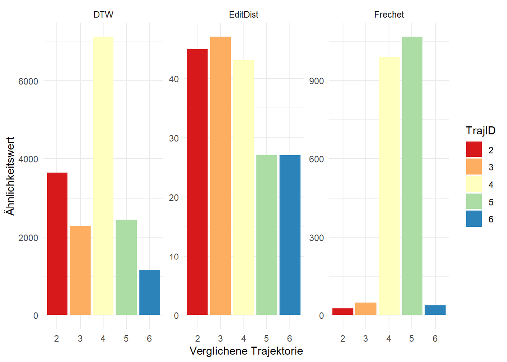

Figure 9: Computed similarities using different measures between trajectory 1 to all other trajectories

```r
results |>
  pivot_longer(cols = c(DTW, EditDist, Frechet), names_to = "Method", values_to = "Similarity") |>
  ggplot(aes(TrajID, y = Similarity, fill = TrajID)) +
  geom_bar(stat = "identity", position = "dodge") +
  scale_fill_brewer(palette = "Spectral") +
  theme_minimal() +
  facet_wrap(.~Method, scales="free")+
  labs(x = "Verglichene Trajektorie", y = "Ähnlichkeitswert")
```

# 4 **References**

Laube, Patrick. 2014. *Computational Movement Analysis*. 2014th ed. SpringerBriefs in Computer Science. Cham: Springer International Publishing AG.

Laube, Patrick, and Ross S. Purves. 2011. “How Fast Is a Cow? Cross-Scale Analysis of Movement Data.” *Transactions in GIS* 15 (3): 401–18. https://doi.org/https://doi.org/10.1111/j.1467-9671.2011.01256.x.

Vlachos, Michail, Dimitrios Gunopoulos, and George Kollios. 2002. “Discovering Similar Multidimensional Trajectories.” In *Proceedings of the 18th International Conference on Data Engineering*, 673. ICDE ’02. USA: IEEE Computer Society.